# EDA & Survival Analysis of the Prostate Cancer ‘prostateSurvival’ Dataset

George Melrose

2024-11-21

## 0 - Domain Knowledge of Prostate Cancer and the ‘prostateSurvival’ dataset

### References

- **CRUK ‘About Cancer’, ‘Prostate Cancer’** - https://www.cancerresearchuk.org/about-cancer/prostate-cancer/stages/localised-prostate-cancer
- **asaur package datasets** - https://cran.r-project.org/web/packages/asaur/asaur.pdf
- **Kaggle grandmaster tanulsingh077 Mr_KnowNothing ‘Prostate Cancer: In Depth Understanding,EDA , Model’** - https://www.kaggle.com/code/tanulsingh077/prostate-cancer-in-depth-understanding-eda-model
- **Oxford Very Short Introductions: Cancer**
- **Oxford Concise Colour Medical Dictionary**
- **“Prostate Cancer Overview” (https://www.youtube.com/watch?v=ZdU5uvyafo4) and “What You Need To Know About Prostate Cancer” (https://www.youtube.com/watch?v=u4O4yNvkpqQ) by Dr.Matthew Cooperberg from the University of California Television Youtube Channel**. Abbreviated *UCTV* .
- **US Government National Cancer Institute “Prostate Cancer Treatment (PDQ®)–Health Professional Version”** - https://www.cancer.gov/types/prostate/hp/prostate-treatment-pdq . Abbreviated *NCI* .

### Prostate Cancer Overview

- The ‘NCI Dictionary of Cancer Terms’ defines the prostate as “A gland in the male reproductive system. The prostate surrounds the part of the urethra (the tube that empties the bladder) just below the bladder, and produces a fluid that forms part of the semen.”

[figure not shown]

```r
knitr::include_graphics("C:/Users/gam55/Documents/Prostate-Cancer-Survival-Analysis/prostate_cross_section.jpg")
```

[Image adapted from NCI *Prostate Cancer Treatment (PDQ®)–Health Professional Version*]

- Prostate cancer is the abnormal growth of cells in the prostate gland. The cancer cells that metastasise to the bones or other body parts are still prostate cancer.
- In the USA, prostate cancer is one of the most common cancers and has one of the highest mortalities -

[figure not shown]

```r
knitr::include_graphics("C:/Users/gam55/Documents/Prostate-Cancer-Survival-Analysis/prostate_cancer_2022.png")
```

- Cancer cells arising in the prostate is not uncommon with aging -

[figure not shown]

```r
knitr::include_graphics("C:/Users/gam55/Documents/Prostate-Cancer-Survival-Analysis/prostate_cancer_cells_w_age.png")
```

- Most men diagnosed with prostate cancer would not know they had it without screening, with most men dieing of other causes. *Aggresive* prostate cancers can spread and be lethal - these need to be found before metastasis.
- Prostate cancer is usually slow in growing. *Five-year survival rate is ~100% for localised cancer*. Even high men with the advanced disease usually live for years with modern treatment.
- The median age of diagnosis is 67 years old [NCI]
- There are several ways of screening and detecting for prostate cancer: having a prostate specific antigen (PSA) blood test; digital rectal exam where a doctor feels the prostate through the rectum; prostate biopsy giving a Gleason pattern/score/grade; additional imaging like bone and CT scans; RNA and Genetic testing.
- *All above information, unless otherwise stated, found through Dr.Cooperberg’s UCTV lectures.*

### Prostate Cancer Symptoms and Diagnosis

- **Symptoms** - Most prostate cancers are found through screening therefore prostate cancer symptoms are infrequent during diagnosis. Nonetheless, prostate tumour growth can produce symptoms of urinary obstruction: decreased urinary stream; nocturia; incomplete bladder emptying.

  These are non-specific symptoms and can also be indicative of **Benign Prostatic Hyperplasia (BPH)** - the prostate becoming enlarged, typically in older men. This can result in obstruction of the neck of the bladder, impairing urination. The bladder dilates and increased pressure is transmitted to the kidney nephrons, impairing and damaging them [Oxford Medical Dictionary].It is rare nowadays with widespread screening however prostate cancer metastasis may have already happened with symptoms of bone pain and pathological fractures.

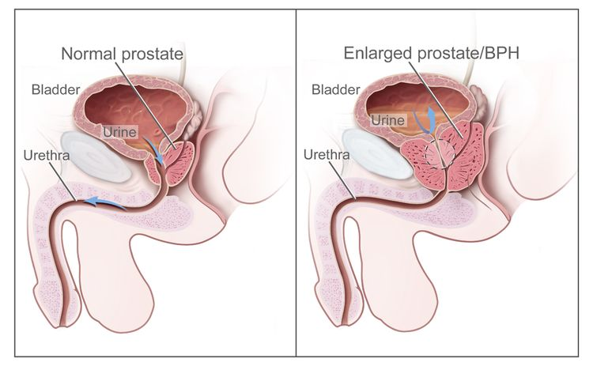

```r
knitr::include_graphics("C:/Users/gam55/Documents/Prostate-Cancer-Survival-Analysis/bph_image.jpg")
```

- **Diagnosis** - Different tests and procedures can be used to diagnose prostate cancer. A **Digital Rectal Exam (DRE)** is when a clinician inserts a finger into the rectum to feel the prostate through the rectal wall for abnormalities.

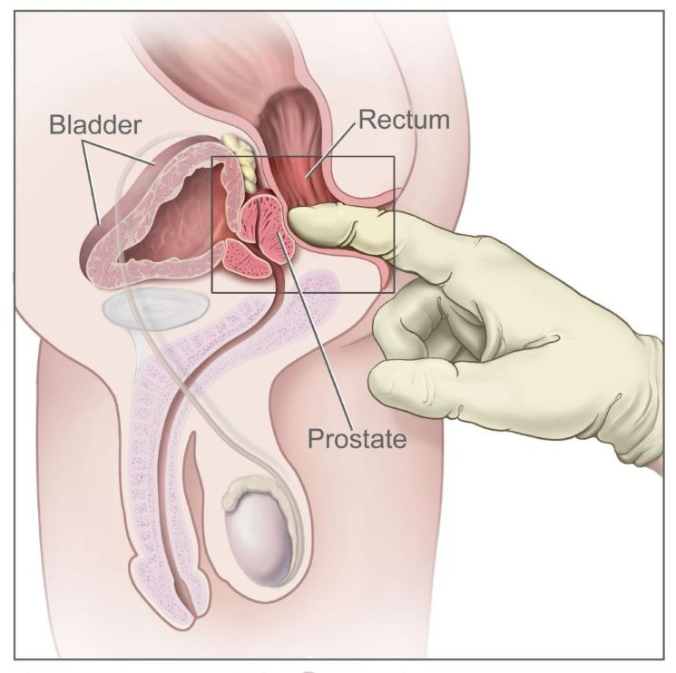

```r
knitr::include_graphics("C:/Users/gam55/Documents/Prostate-Cancer-Survival-Analysis/dre.jpg")
```

**Prostate-specific antigen (PSA) test** - A test to measure the levels of PSA in the blood. PSA levels are elevated in prostate cancer but can also be elevated by stress and inflammation on the prostate - after a long bicycle ride for example.

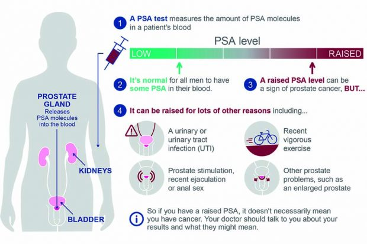

```r
knitr::include_graphics("C:/Users/gam55/Documents/Prostate-Cancer-Survival-Analysis/uk_gov_psa_guidance.jpg")
```

**Prostate-specific membrane antigen (PSMA) Positron Emission Tomography (PET) scan** - An imaging procedure to help find prostate cancer cells that have spread outside of the prostate, into bone, lymph nodes, or other organs. A cell-targeting molecule linked to a radioactive substance is injected into the body and travels through the blood. It attaches to a protein called PSMA that is found on the surface of prostate cancer cells. A PET scanner detects high concentrations of the radioactive molecule and shows where the prostate cancer cells are in the body.

**Transrectal ultrasound** - a probe approximately the size of a finger is inserted into the rectum to check the prostate. The probe ultrasound off internal tissues or organs and make echoes. The echoes form a picture of body tissues called a sonogram. Transrectal ultrasound may be used during a biopsy procedure - transrectal ultrasound guided biopsy.

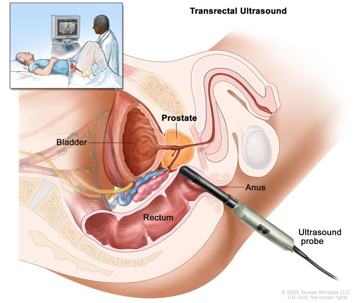

```r
knitr::include_graphics("C:/Users/gam55/Documents/Prostate-Cancer-Survival-Analysis/transrectal_ultrasound.jpg")
```

**Transrectal magnetic resonance imaging (MRI)** - A probe that gives off radio waves is inserted into the rectum near the prostate. This helps the MRI machine make clearer pictures of the prostate and nearby tissue. A transrectal MRI is done to find out if the cancer has spread outside the prostate into nearby tissues. This procedure is also called nuclear magnetic resonance imaging (NMRI). Transrectal MRI may be used during a biopsy procedure - transrectal MRI guided biopsy.

### Staging Prostate Cancer using the Grade Group and PSA Level

If cancer is found, it will be given a grade. The grade of the cancer describes how abnormal the cancer cells look under a microscope and how quickly the cancer is likely to spread. The grade is also called the **Gleason score**.

The prostate tissue samples are checked to see how much the tumor tissue is like the normal prostate tissue and to find the two main cell patterns. The primary pattern describes the most common tissue pattern, and the secondary pattern describes the next most common pattern. Each pattern is given a grade from 3 to 5, with grade 3 looking the most like normal prostate tissue and grade 5 looking the most abnormal. The two grades are then added to get a Gleason score.

The Gleason score can range from 6 to 10. The higher the Gleason score, the more likely the cancer will metastasise. A score of 6 is a low-grade cancer; a score of 7 is a medium-grade cancer; and a score of 8, 9, or 10 is a high-grade cancer. For example, if the most common tissue pattern is grade 3 and the secondary pattern is grade 4, it means that most of the cancer is grade 3 and less of the cancer is grade 4. The grades are added for a Gleason score of 7, and it is a medium-grade cancer. The score may be written as 3+4=7, Gleason 7/10, or combined Gleason score of 7.

- **Stage I** - Cancer is only in the prostate. The cancer is not felt during a DRE and is found by needle biopsy done for high PSA level or in a sample of tissue removed during surgery. The PSA level is less than 10 and the Grade Group is 1; OR the cancer is felt during a DRE and is found in one-half or less of one side of the prostate. The PSA level is less than 10 and the Grade Group is 1.

[figure not shown]

```r
knitr::include_graphics("C:/Users/gam55/Documents/Prostate-Cancer-Survival-Analysis/stage1.jpg")
```

- **Stage I** - Cancer is only in the prostate. The cancer is not felt during a DRE and is found by needle biopsy done for high PSA level or in a sample of tissue removed during surgery. The PSA level is less than 10 and the Grade Group is 1; OR the cancer is felt during a DRE and is found in one-half or less of one side of the prostate. The PSA level is less than 10 and the Grade Group is 1.

### The asaur ‘prostatesurvival’ dataset

The description of the dataset from the *“Applied Survival Analysis Using R”* *(asaur)* package -

“This data set contains survival times for two competing causes: time from prostate cancer diagnosis to death from prostate cancer, and time from prostate cancer diagnosis to death from other causes. The data set also contains information on several risk factors. The data in this data set are simulated from detailed competing risk survival curves and counts of numbers of patients per group presented in Lu-Yao et al. (2009).

Thus, the simulated data presented here contain many of the characteristics of the original SEER-Medicare prostate cancer data used in Lu-Yao et al. (2009).”

The dataframe has 14,294 observations on the following 5 variables:

- **grade** - a factor with levels ‘mode’ (moderately differentiated) and ‘poor’ (poorly differentiated). In simplified terms, moderately differentiated tumors correspond to a Gleason score of 6-7 (intermediate risk). Poorly differentiated tumors correspond to a Gleason score of 8–10 (high risk).
- **stage** - a factor with levels T1ab (Stage T1, clinically diagnosed), T1c (Stage T1, diagnosed via a PSA test and a biopsy), and T2 (Stage T2, the cancer is completely in the prostate gland).
- **ageGroup** - a factor with levels 66-69, 70-74, 75-79, 80+ .
- **survTime** - time from diagnosis to death or last date known alive. Not stated in the asaur package’s description of the data but this is presumably in days. .
- **status** - a censoring variable, 0, (censored), 1 (death from prostate cancer), and 2 (death from other causes).

## 1 - Formatting & Initial look at ‘asaur’ Data

```r
str(prostateSurvival)
```

```
## 'data.frame':    14294 obs. of  5 variables:
##  $ grade   : Factor w/ 2 levels "mode","poor": 1 1 2 1 1 2 2 1 1 2 ...
##  $ stage   : Factor w/ 3 levels "T1ab","T1c","T2": 2 1 2 3 2 3 2 1 2 3 ...
##  $ ageGroup: Factor w/ 4 levels "66-69","70-74",..: 4 3 3 2 2 3 4 4 3 3 ...
##  $ survTime: int  18 23 37 27 42 38 18 78 47 13 ...
##  $ status  : int  0 0 0 0 0 2 0 0 0 0 ...
```

```r
datatable(prostateSurvival)
```

|  | grade | stage | ageGroup | survTime | status |
| --- | --- | --- | --- | --- | --- |
| 1 | mode | T1c | 80+ | 18 | 0 |
| 2 | mode | T1ab | 75-79 | 23 | 0 |
| 3 | poor | T1c | 75-79 | 37 | 0 |
| 4 | mode | T2 | 70-74 | 27 | 0 |
| 5 | mode | T1c | 70-74 | 42 | 0 |
| 6 | poor | T2 | 75-79 | 38 | 2 |
| 7 | poor | T1c | 80+ | 18 | 0 |
| 8 | mode | T1ab | 80+ | 78 | 0 |
| 9 | mode | T1c | 75-79 | 47 | 0 |
| 10 | poor | T2 | 75-79 | 13 | 0 |

[output cut: 14284 more lines]

```r
prostateSurvival$status_factor <- factor(
  prostateSurvival$status,
  levels = c(0, 1, 2),
  labels = c("Censored", "Death from Prostate Cancer", "Death from Other Causes")
)
```

```r
# Create a new death variable with "No" as the first level
prostateSurvival$death <- factor(
  ifelse(prostateSurvival$status_factor %in% c("Death from Prostate Cancer", "Death from Other Causes"), "Yes", "No"),
  levels = c("No", "Yes")  # Specify the order of levels: "No" first, then "Yes"
)

# Create a new binary death variable
prostateSurvival$death_binary <- ifelse(prostateSurvival$status_factor %in% c("Death from Prostate Cancer", "Death from Other Causes"), 1, 0)
```

```r
levels(prostateSurvival$grade)
```

```
## [1] "mode" "poor"
```

```r
levels(prostateSurvival$stage)
```

```
## [1] "T1ab" "T1c"  "T2"
```

```r
levels(prostateSurvival$ageGroup)
```

```
## [1] "66-69" "70-74" "75-79" "80+"
```

```r
levels(prostateSurvival$status_factor)
```

```
## [1] "Censored"                   "Death from Prostate Cancer"
## [3] "Death from Other Causes"
```

```r
#above levels for each variable are all correct#
```

```r
p <- ff_glimpse(prostateSurvival)

continuous_glimpse <- as.data.frame(p$Continuous)

categorical_glimpse <- as.data.frame(p$Categorical)

flextable(continuous_glimpse)
```

| label | var_type | n | missing_n | missing_percent | mean | sd | min | quartile_25 | median | quartile_75 | max |
| --- | --- | --- | --- | --- | --- | --- | --- | --- | --- | --- | --- |
| survTime | <int> | 14,294 | 0 | 0.0 | 39.0 | 31.1 | 0.0 | 13.0 | 30.0 | 60.0 | 119.0 |
| status | <int> | 14,294 | 0 | 0.0 | 0.5 | 0.8 | 0.0 | 0.0 | 0.0 | 1.0 | 2.0 |
| death_binary | <dbl> | 14,294 | 0 | 0.0 | 0.3 | 0.5 | 0.0 | 0.0 | 0.0 | 1.0 | 1.0 |

```r
flextable(categorical_glimpse)
```

| label | var_type | n | missing_n | missing_percent | levels_n | levels | levels_count | levels_percent |
| --- | --- | --- | --- | --- | --- | --- | --- | --- |
| grade | <fct> | 14,294 | 0 | 0.0 | 2 | "mode", "poor" | 10988, 3306 | 77, 23 |
| stage | <fct> | 14,294 | 0 | 0.0 | 3 | "T1ab", "T1c", "T2" | 3881, 4493, 5920 | 27, 31, 41 |
| ageGroup | <fct> | 14,294 | 0 | 0.0 | 4 | "66-69", "70-74", "75-79", "80+" | 1423, 2952, 4313, 5606 | 10, 21, 30, 39 |
| status_factor | <fct> | 14,294 | 0 | 0.0 | 3 | "Censored", "Death from Prostate Cancer", "Death from Other Causes" | 10255, 799, 3240 | 71.7, 5.6, 22.7 |
| death | <fct> | 14,294 | 0 | 0.0 | 2 | "No", "Yes" | 10255, 4039 | 72, 28 |

There are several points to note from the above glimpse results. There is no missing data in this dataset -

- **survTime** - The minimum and maximum survival times are 0 and 119 days respectively. The mean survival time is 39 times with a high standard deviation of 31.1 .
- **grade** - There are 10,988 rows (77%) with “mode” and 3,306 rows (23%) with poor.
- **stage** - There are 3,881 (27%) rows with “T1ab”, 4,493 (31%) with “T1c”, and 5,920 (41%) with “T2”.
- **ageGroup** - There are 1,423 (10%) rows with “66-69”, 2,952 (21%) with “70-74”, and 4,313 (30%) with “75-79”, and 5,606 (39%) with “80+”.
- **status_factor** - There are 10,255 rows (71.7%) with “Censored”, 799 (5.6%) with “Death from Prostate Cancer”, and 3,240(22.7%) with 2 “Death from Other Causes”.

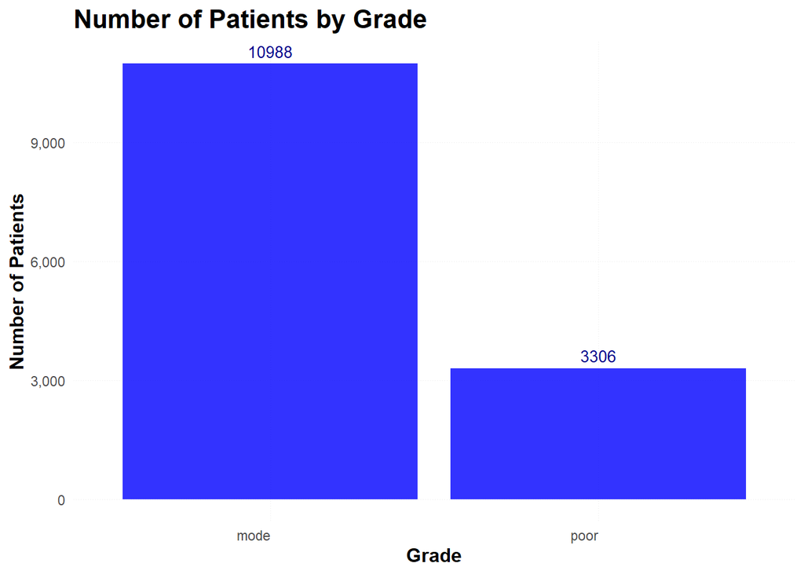

```r
grade_counts <- prostateSurvival %>%
  group_by(grade) %>%
  summarise(patient_count = n()) %>%
  mutate(percentage = (patient_count / sum(patient_count)) * 100,
        percentage = signif(percentage, 3)) %>%
  arrange(grade)



ggplot(grade_counts, aes(x = grade, y = patient_count)) +
  geom_col(fill = "blue", alpha = 0.8) +
  geom_text(aes(label = patient_count), vjust = -0.5, size = 3.5, color = "darkblue") +
  scale_y_continuous(labels = comma) +
  labs(title = "Number of Patients by Grade",
       x = "Grade",
       y = "Number of Patients") +
  theme_minimal() +
  theme(
    plot.title = element_text(size = 16, face = "bold"),
    plot.subtitle = element_text(size = 12),
    axis.title.x = element_text(size = 12, face = "bold"),
    axis.title.y = element_text(size = 12, face = "bold"),
    axis.text.x = element_text(hjust = 1),
    panel.grid.major = element_line(size = 0.1, linetype = 'dotted'),
    panel.grid.minor = element_blank()
  )
```

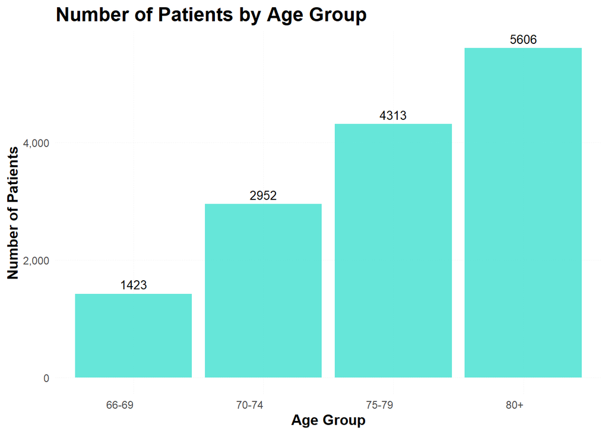

```r
age_counts <- prostateSurvival %>%
  group_by(ageGroup) %>%
  summarise(patient_count = n()) %>%
  mutate(percentage = (patient_count / sum(patient_count)) * 100,
        percentage = signif(percentage, 3)) %>%
  arrange(ageGroup)



ggplot(age_counts, aes(x = ageGroup, y = patient_count)) +
  geom_col(fill = "turquoise", alpha = 0.8) +
  geom_text(aes(label = patient_count), vjust = -0.5, size = 3.5, color = "black") +
  scale_y_continuous(labels = comma) +
  labs(title = "Number of Patients by Age Group",
       x = "Age Group",
       y = "Number of Patients") +
  theme_minimal() +
  theme(
    plot.title = element_text(size = 16, face = "bold"),
    plot.subtitle = element_text(size = 12),
    axis.title.x = element_text(size = 12, face = "bold"),
    axis.title.y = element_text(size = 12, face = "bold"),
    axis.text.x = element_text(hjust = 1),
    panel.grid.major = element_line(size = 0.1, linetype = 'dotted'),
    panel.grid.minor = element_blank()
  )
```

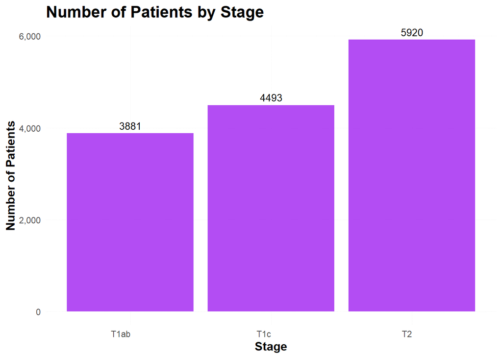

```r
stage_counts <- prostateSurvival %>%
  group_by(stage) %>%
  summarise(patient_count = n()) %>%
  mutate(percentage = (patient_count / sum(patient_count)) * 100,
        percentage = signif(percentage, 3)) %>%
  arrange(stage)



ggplot(stage_counts, aes(x = stage, y = patient_count)) +
  geom_col(fill = "purple", alpha = 0.8) +
  geom_text(aes(label = patient_count), vjust = -0.5, size = 3.5, color = "black") +
  scale_y_continuous(labels = comma) +
  labs(title = "Number of Patients by Stage",
       x = "Stage",
       y = "Number of Patients") +
  theme_minimal() +
  theme(
    plot.title = element_text(size = 16, face = "bold"),
    plot.subtitle = element_text(size = 12),
    axis.title.x = element_text(size = 12, face = "bold"),
    axis.title.y = element_text(size = 12, face = "bold"),
    axis.text.x = element_text(hjust = 1),
    panel.grid.major = element_line(size = 0.1, linetype = 'dotted'),
    panel.grid.minor = element_blank()
  )
```

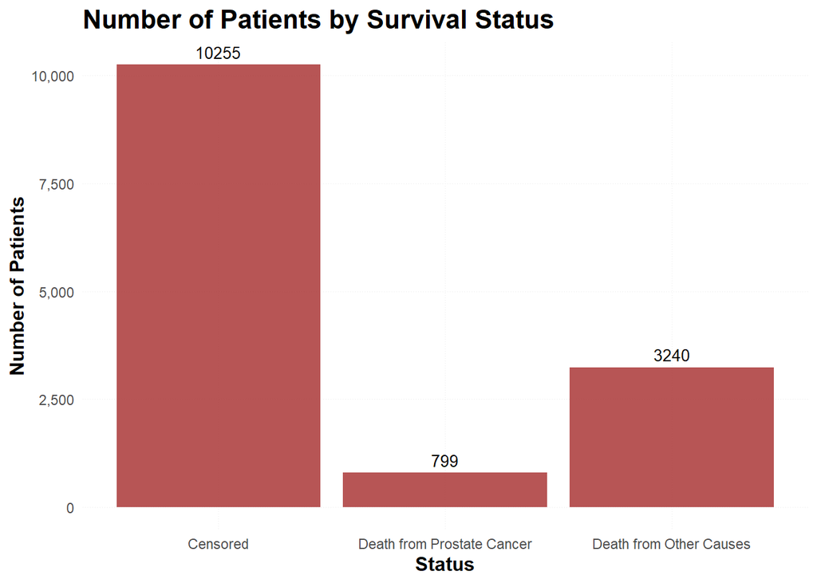

```r
surv_counts <- prostateSurvival %>%
  group_by(status_factor) %>%
  summarise(patient_count = n()) %>%
  mutate(percentage = (patient_count / sum(patient_count)) * 100,
        percentage = signif(percentage, 3)) %>%
  arrange(status_factor)



ggplot(surv_counts, aes(x = status_factor, y = patient_count)) +
  geom_col(fill = "brown", alpha = 0.8) +
  geom_text(aes(label = patient_count), vjust = -0.5, size = 3.5, color = "black") +
  scale_y_continuous(labels = comma) +
  labs(title = "Number of Patients by Survival Status",
       x = "Status",
       y = "Number of Patients") +
  theme_minimal() +
  theme(
    plot.title = element_text(size = 16, face = "bold"),
    plot.subtitle = element_text(size = 12),
    axis.title.x = element_text(size = 12, face = "bold"),
    axis.title.y = element_text(size = 12, face = "bold"),
    axis.text.x = element_text(hjust = 0.5, vjust = 1),
    panel.grid.major = element_line(size = 0.1, linetype = 'dotted'),
    panel.grid.minor = element_blank()
  )
```

## 2 - EDA of ‘asaur’ Data

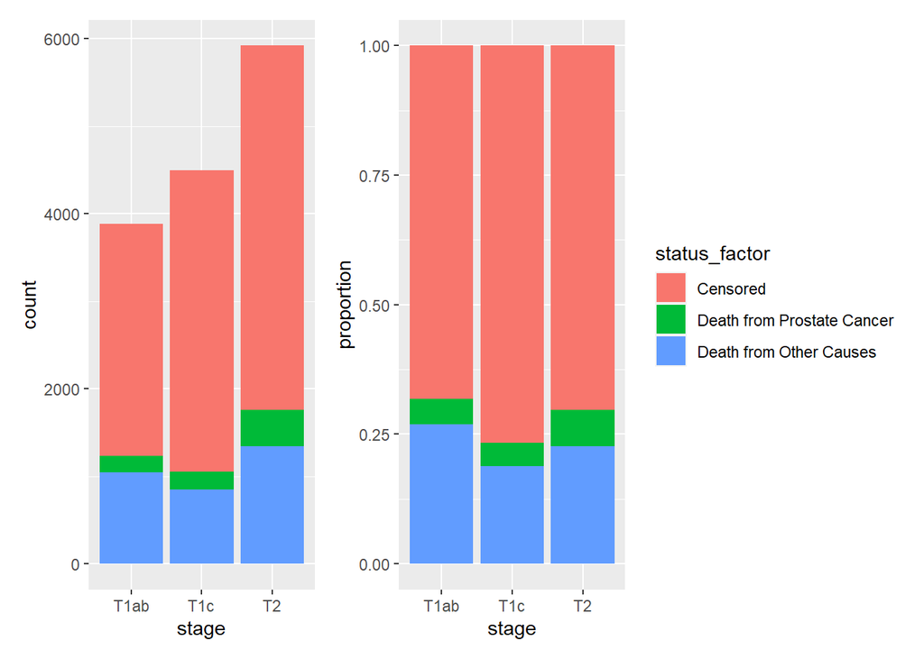

```r
p1 <- prostateSurvival %>%
  ggplot(aes(x = stage, fill = status_factor)) +
  geom_bar() +
  theme(legend.position = "none")

p2 <- prostateSurvival %>%
  ggplot(aes(x = stage, fill = status_factor)) +
  geom_bar(position = "fill") +
  ylab("proportion")

p1 + p2
```

As the above plots show, the vast majority of patients are censored in this dataset so it makes more sense to remove these rows to have a better insight if the ‘tumour’ stage affects death from survival status (status_factor).

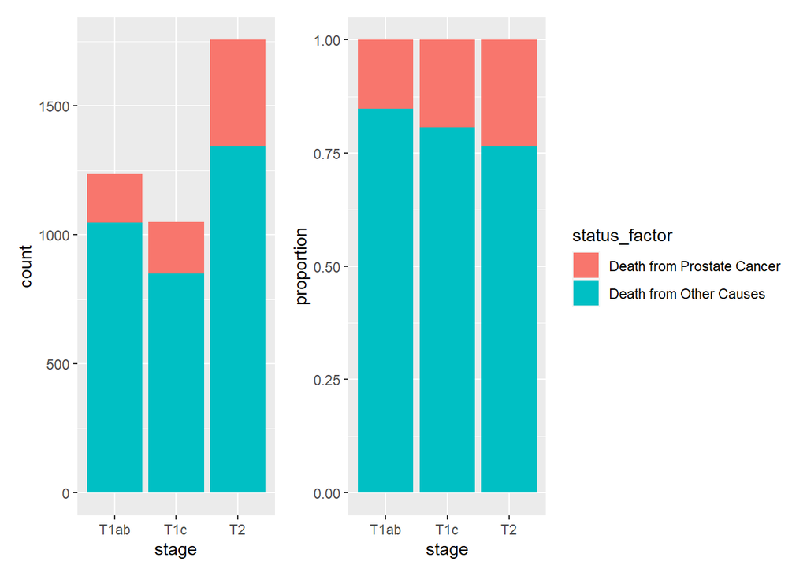

```r
prostateSurvival_wo_censoring <- prostateSurvival %>% filter(status != 0)

p1 <- prostateSurvival_wo_censoring  %>%
  ggplot(aes(x = stage, fill = status_factor)) +
  geom_bar() +
  theme(legend.position = "none")

p2 <- prostateSurvival_wo_censoring  %>%
  ggplot(aes(x = stage, fill = status_factor)) +
  geom_bar(position = "fill") +
  ylab("proportion")

p1 + p2
```

Much better, now we can clearly see that the proportion of patients who die from prostate cancer increases as the stage increases.

For ‘ageGroup’ and ‘grade’ as well -

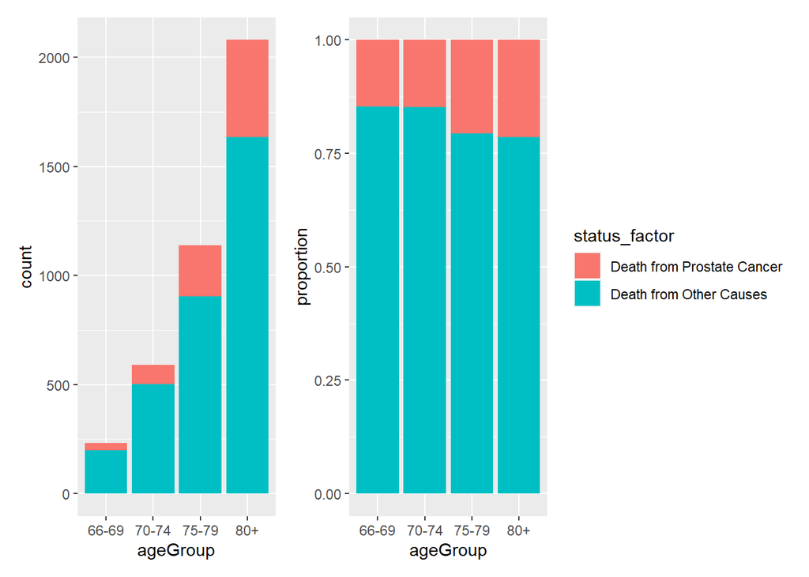

```r
p1 <- prostateSurvival_wo_censoring  %>%
  ggplot(aes(x = ageGroup, fill = status_factor)) +
  geom_bar() +
  theme(legend.position = "none")

p2 <- prostateSurvival_wo_censoring  %>%
  ggplot(aes(x = ageGroup, fill = status_factor)) +
  geom_bar(position = "fill") +
  ylab("proportion")

p1 + p2
```

In the above faceted bar charts we can see that most deaths are skewed towards the older age groups and that the proportion of patients dying from prostate cancer stays the same from 66-69 to 70-74, there is an increase for 75-79 and 80+.

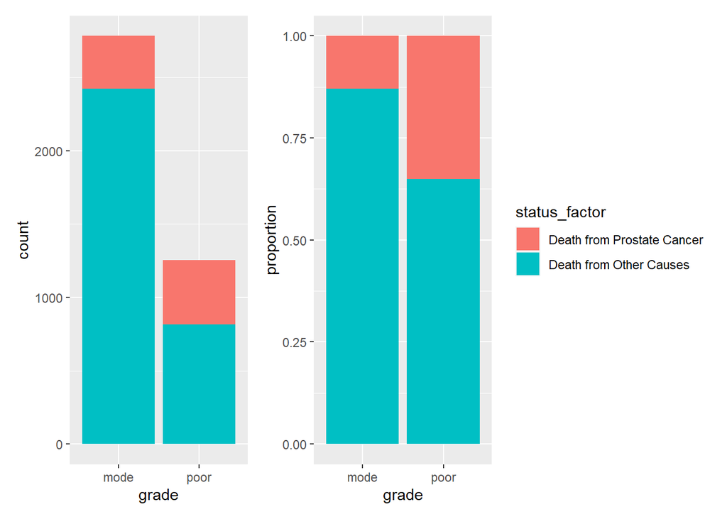

```r
p1 <- prostateSurvival_wo_censoring  %>%
  ggplot(aes(x = grade, fill = status_factor)) +
  geom_bar() +
  theme(legend.position = "none")

p2 <- prostateSurvival_wo_censoring  %>%
  ggplot(aes(x = grade, fill = status_factor)) +
  geom_bar(position = "fill") +
  ylab("proportion")

p1 + p2
```

Again, when the grade moves to the more severe ‘poorly differentiated’ (a higher Gleason grade), the deaths from prostate cancer increase in proportion.

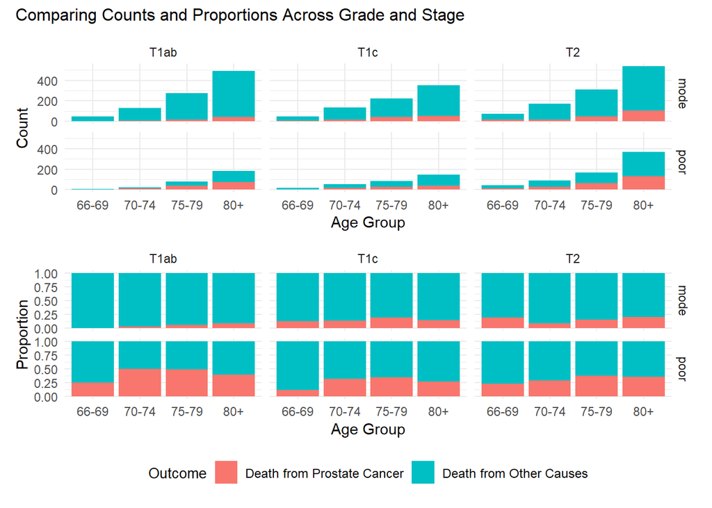

```r
p1 <- prostateSurvival_wo_censoring %>%
  ggplot(aes(x = ageGroup, fill = status_factor)) +
  geom_bar(position = position_stack(reverse = TRUE)) +
  facet_grid(grade ~ stage) +
  labs(
    x = "Age Group",
    y = "Count",
    fill = "Outcome" # Setting the legend title
  ) +
  theme_minimal() +
  theme(legend.position = "none")

p2 <- prostateSurvival_wo_censoring %>%
  ggplot(aes(x = ageGroup, fill = status_factor)) +
  geom_bar(position = position_fill(reverse = TRUE)) +
  facet_grid(grade ~ stage) +
  labs(
    x = "Age Group",
    y = "Proportion",
    fill = "Outcome" # Setting the legend title
  ) +
  theme_minimal() +
  theme(
    legend.position = "bottom",
    legend.title = element_text(size = 10),
    legend.text = element_text(size = 9))

# Combine plots using patchwork
combined_plot <- p1 / p2 +
  plot_annotation(
    subtitle = "Comparing Counts and Proportions Across Grade and Stage",
    theme = theme(plot.title = element_text(size = 16, face = "bold"),
                  plot.subtitle = element_text(size = 12))
  )

# Display the combined plot
combined_plot
```

```r
 # Save the combined plot as an image
# ggsave(
#   filename = "combined_plot.png",    # File name
#   plot = combined_plot,             # Plot object
#   width = 10,                       # Width in inches
#   height = 8,                       # Height in inches
#   dpi = 300                         # Resolution in dots per inch (high-quality)
# )
```

Analysing the above faceted bar plots, one can see that count of deaths always rises with age, in all different levels of the factor variables. The proportions table below shows no obvious correlation between death and prostate cancer, with a particular facet except for perhaps “T1ab”&“mode” and “T2”&“poor” where the proportions of death from prostate cancer rise with age slightly.

```r
# Remove unused levels from the factor
prostateSurvival_wo_censoring$status_factor <- droplevels(prostateSurvival_wo_censoring$status_factor)

# Check the levels after removal
levels(prostateSurvival_wo_censoring$status_factor)
```

```
## [1] "Death from Prostate Cancer" "Death from Other Causes"
```

```r
tbl <- prostateSurvival_wo_censoring %>% summary_factorlist(dependent = "status_factor", explanatory = c("grade", "stage", "ageGroup"), p = TRUE)

datatable(tbl)
```

|  | label | levels | Death from Prostate Cancer | Death from Other Causes | p |
| --- | --- | --- | --- | --- | --- |
| 1 | grade | mode | 359 (44.9) | 2425 (74.8) | &lt;0.001 |
| 2 |  | poor | 440 (55.1) | 815 (25.2) |  |
| 3 | stage | T1ab | 187 (23.4) | 1047 (32.3) | &lt;0.001 |
| 4 |  | T1c | 202 (25.3) | 848 (26.2) |  |
| 5 |  | T2 | 410 (51.3) | 1345 (41.5) |  |
| 6 | ageGroup | 66-69 | 34 (4.3) | 198 (6.1) | 0.001 |
| 7 |  | 70-74 | 87 (10.9) | 503 (15.5) |  |
| 8 |  | 75-79 | 234 (29.3) | 904 (27.9) |  |
| 9 |  | 80+ | 444 (55.6) | 1635 (50.5) |  |

```r
tbl_widget <- datatable(tbl)
saveWidget(tbl_widget, "summary_table.html", selfcontained = TRUE)
```

The above table shows multiple variables by outcome with hypothesis tests: Death by Prostate Cancer vs Death by Other Causes for by age group and grade & stage of prostate tumour.

- The difference between mode (359 deaths) and poor grade (440 deaths) categories is statistically significant (p < 0.001). Poor grade has a higher percentage of deaths from prostate cancer (55.1%) compared to mode (44.9%), and a lower percentage of deaths from other causes (25.2% vs 74.8%).
- The stage of cancer (T1ab, T1c, T2) is significantly related to the distribution of death causes (p < 0.001). T2 stage has the highest percentage of deaths from prostate cancer (51.3%), while T1ab has the lowest (23.4%). This suggests that patients with T2 stage cancer are more likely to die from prostate cancer, whereas those with T1ab may have a higher proportion of deaths from other causes.
- The age group variable shows a statistically significant association (p = 0.001) between age and the cause of death. As age increases, the percentage of deaths from prostate cancer rises, particularly in the 80+ group (55.6%). Conversely, the percentage of deaths from other causes is higher in the younger age groups, although the difference is not as stark as for prostate cancer. Older patients are more likely to die from prostate cancer, possibly due to the longer duration of their disease.

## 3 - Fitting a Logistic Regression model on ‘asaur’ Data

### EDA

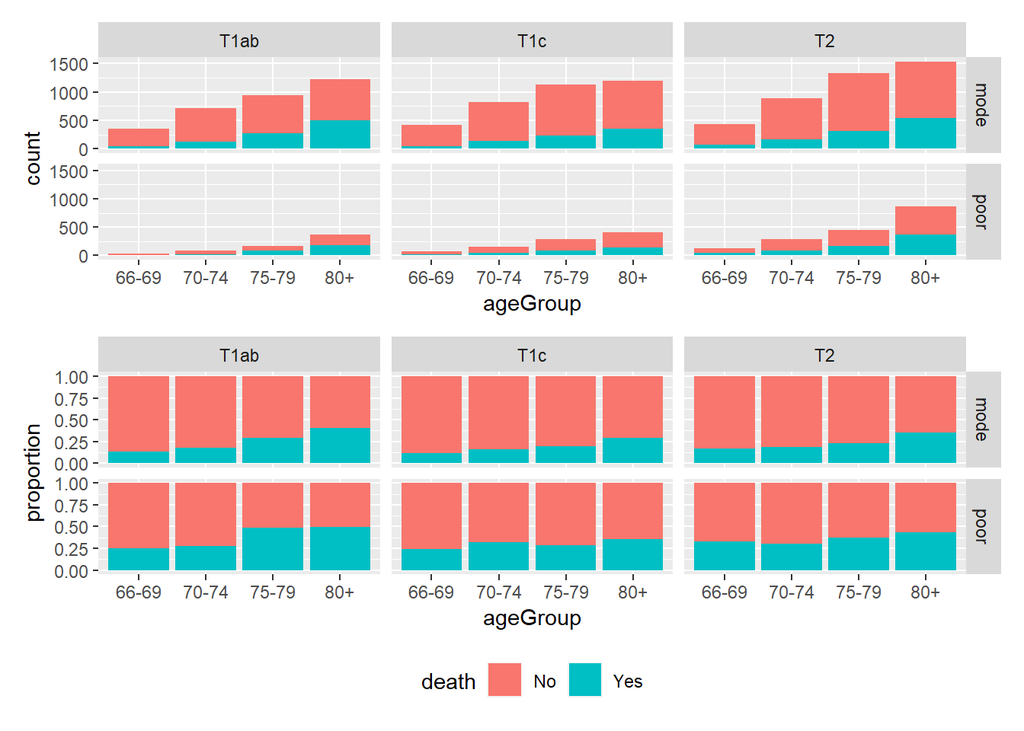

```r
p1 <- prostateSurvival %>%
  ggplot(aes(x = ageGroup, fill=death)) +
  geom_bar(position = position_stack(reverse = FALSE)) +
  facet_grid(grade ~ stage) +
  theme(legend.position = "none")

p2 <- prostateSurvival %>%
  ggplot(aes(x = ageGroup, fill=death)) +
  geom_bar(position = position_fill(reverse = FALSE)) +
  facet_grid(grade ~ stage)+
  theme(legend.position = "bottom") +
  ylab("proportion")

p1 / p2
```

```r
dependent <- "death"
explanatory <- c("grade", "stage", "ageGroup")
tbl <- prostateSurvival %>%
  summary_factorlist(dependent, explanatory, p = TRUE,
                     add_dependent_label = TRUE)

datatable(tbl)
```

|  | Dependent: death |  | No | Yes | p |
| --- | --- | --- | --- | --- | --- |
| 1 | grade | mode | 8204 (80.0) | 2784 (68.9) | &lt;0.001 |
| 2 |  | poor | 2051 (20.0) | 1255 (31.1) |  |
| 3 | stage | T1ab | 2647 (25.8) | 1234 (30.6) | &lt;0.001 |
| 4 |  | T1c | 3443 (33.6) | 1050 (26.0) |  |
| 5 |  | T2 | 4165 (40.6) | 1755 (43.5) |  |
| 6 | ageGroup | 66-69 | 1191 (11.6) | 232 (5.7) | &lt;0.001 |
| 7 |  | 70-74 | 2362 (23.0) | 590 (14.6) |  |
| 8 |  | 75-79 | 3175 (31.0) | 1138 (28.2) |  |
| 9 |  | 80+ | 3527 (34.4) | 2079 (51.5) |  |

### Model Assumptions

From the *HealthyR* textbook -

The assumptions are:

1.Binary dependent variable - this is obvious, but as above we need to check (alive, death from disease, death from other causes doesn’t work);

2. Independence of observations - the observations should not be repeated measurements or matched data;
3. Linearity of continuous explanatory variables and the log-odds outcome - take age as an example. If the outcome, say death, gets more frequent or less frequent as age rises, the model will work well. However, say children and the elderly are at high risk of death, but those in middle years are not, then the relationship is not linear. Or more correctly, it is not monotonic, meaning that the response does not only go in one direction;
4. No multicollinearity - explanatory variables should not be highly correlated with each other.

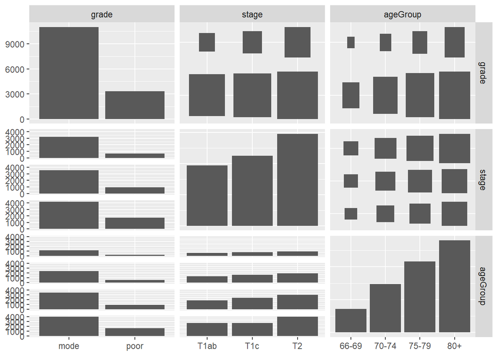

```r
prostateSurvival %>%
  remove_labels() %>%  # ggpairs doesn't work well with labels
  ggpairs(columns = explanatory)
```

```r
# Create a contingency table for the categorical variables
table_data <- table(prostateSurvival$grade, prostateSurvival$stage)

# Calculate Cramér's V statistic
assocstats(table_data)
```

```
##                     X^2 df P(> X^2)
## Likelihood Ratio 227.62  2        0
## Pearson          226.55  2        0
##
## Phi-Coefficient   : NA
## Contingency Coeff.: 0.125
## Cramer's V        : 0.126
```

```r
# Create a contingency table for the categorical variables
table_data <- table(prostateSurvival$grade, prostateSurvival$ageGroup)

# Calculate Cramér's V statistic
assocstats(table_data)
```

```
##                     X^2 df P(> X^2)
## Likelihood Ratio 211.12  3        0
## Pearson          211.47  3        0
##
## Phi-Coefficient   : NA
## Contingency Coeff.: 0.121
## Cramer's V        : 0.122
```

```r
# Create a contingency table for the categorical variables
table_data <- table(prostateSurvival$stage, prostateSurvival$ageGroup)

# Calculate Cramér's V statistic
assocstats(table_data)
```

```
##                     X^2 df   P(> X^2)
## Likelihood Ratio 35.311  6 3.7510e-06
## Pearson          35.087  6 4.1463e-06
##
## Phi-Coefficient   : NA
## Contingency Coeff.: 0.049
## Cramer's V        : 0.035
```

```r
# Fit a linear model (you can use any suitable model, here just for the sake of the example)
model <- lm(death_binary ~ grade + stage + ageGroup, data = prostateSurvival)

# Calculate VIF
car::vif(model)
```

```
##              GVIF Df GVIF^(1/(2*Df))
## grade    1.031290  1        1.015524
## stage    1.018532  2        1.004601
## ageGroup 1.017442  3        1.002886
```

```r
prostateSurvival %>% finalfit(dependent, explanatory, metrics = TRUE)
```

```
## [[1]]
##  Dependent: death                No         Yes          OR (univariable)
##             grade  mode 8204 (74.7) 2784 (25.3)                         -
##                    poor 2051 (62.0) 1255 (38.0) 1.80 (1.66-1.96, p<0.001)
##             stage  T1ab 2647 (68.2) 1234 (31.8)                         -
##                     T1c 3443 (76.6) 1050 (23.4) 0.65 (0.59-0.72, p<0.001)
##                      T2 4165 (70.4) 1755 (29.6) 0.90 (0.83-0.99, p=0.024)
##          ageGroup 66-69 1191 (83.7)  232 (16.3)                         -
##                   70-74 2362 (80.0)  590 (20.0) 1.28 (1.09-1.52, p=0.004)
##                   75-79 3175 (73.6) 1138 (26.4) 1.84 (1.58-2.15, p<0.001)
##                     80+ 3527 (62.9) 2079 (37.1) 3.03 (2.61-3.53, p<0.001)
##         OR (multivariable)
##                          -
##  1.67 (1.53-1.82, p<0.001)
##                          -
##  0.65 (0.59-0.72, p<0.001)
##  0.84 (0.77-0.92, p<0.001)
##                          -
##  1.27 (1.07-1.50, p=0.005)
##  1.80 (1.54-2.11, p<0.001)
##  2.81 (2.42-3.28, p<0.001)
##
## [[2]]
##
##  Number in dataframe = 14294, Number in model = 14294, Missing = 0, AIC = 16395.9, C-statistic = 0.633, H&L = Chi-sq(8) 11.81 (p=0.160)
```

```r
explanatory = c("grade", "ageGroup")

prostateSurvival %>% finalfit(dependent, explanatory, metrics = TRUE)
```

```
## [[1]]
##  Dependent: death                No         Yes          OR (univariable)
##             grade  mode 8204 (74.7) 2784 (25.3)                         -
##                    poor 2051 (62.0) 1255 (38.0) 1.80 (1.66-1.96, p<0.001)
##          ageGroup 66-69 1191 (83.7)  232 (16.3)                         -
##                   70-74 2362 (80.0)  590 (20.0) 1.28 (1.09-1.52, p=0.004)
##                   75-79 3175 (73.6) 1138 (26.4) 1.84 (1.58-2.15, p<0.001)
##                     80+ 3527 (62.9) 2079 (37.1) 3.03 (2.61-3.53, p<0.001)
##         OR (multivariable)
##                          -
##  1.65 (1.52-1.79, p<0.001)
##                          -
##  1.27 (1.08-1.51, p=0.005)
##  1.80 (1.54-2.11, p<0.001)
##  2.85 (2.46-3.33, p<0.001)
##
## [[2]]
##
##  Number in dataframe = 14294, Number in model = 14294, Missing = 0, AIC = 16465.5, C-statistic = 0.624, H&L = Chi-sq(8) 7.74 (p=0.460)
```